# Quiz 2

### 3.-

Load the cement data using the commands

library(AppliedPredictiveModeling)

data(concrete); library(caret); set.seed(1000)

inTrain = createDataPartition(mixtures$CompressiveStrength, p = 3/4)[[1]]

training = mixtures[ inTrain,];testing = mixtures[-inTrain,]

Make a histogram and confirm the SuperPlasticizer variable is skewed. Normally you might use the log transform to try to make the data more symmetric. Why would that be a poor choice for this variable?

- There are a large number of values that are the same and even if you took the log(SuperPlasticizer + 1) they would still all be identical so the distribution would not be symmetric. (Correct)
- The log transform does not reduce the skewness of the non-zero values of SuperPlasticizer
- The log transform is not a monotone transformation of the data.
- The SuperPlasticizer data include negative values so the log transform can not be performed.

Explication ->

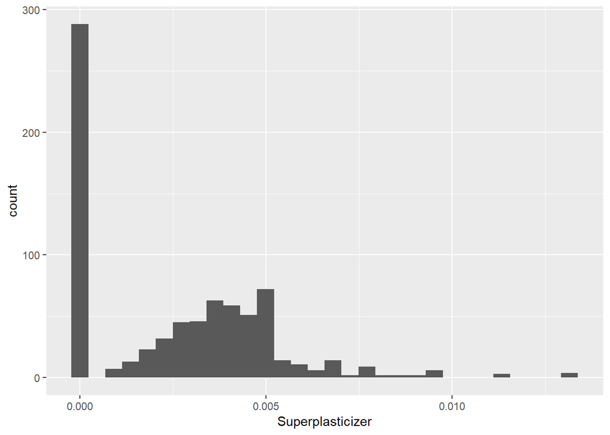

```r
suppressWarnings(library(AppliedPredictiveModeling))
data(concrete)
suppressWarnings(library(caret))
set.seed(1000)
inTrain = createDataPartition(mixtures$CompressiveStrength, p = 3/4)[[1]]
training = mixtures[ inTrain,]
testing = mixtures[-inTrain,]

# First of all, lets do the histogram:

ggplot(data =training, aes(x=Superplasticizer)) + geom_histogram()
```

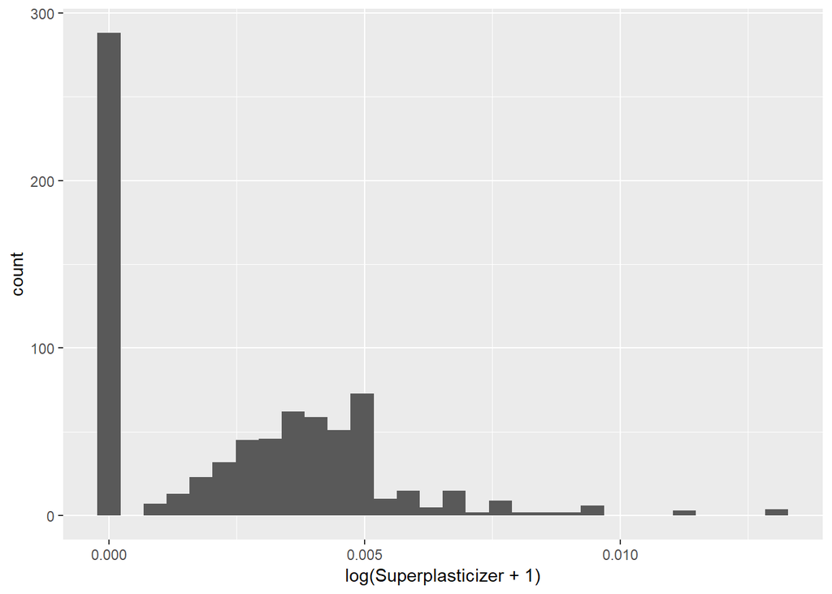

```r
# There are values which are 0, so we cannot do the log() transform. Lets prove with log(...+1)
ggplot(data =training, aes(x=log(Superplasticizer+1))) + geom_histogram()
```

```r
# Values still look identical, so the answer is "There are a large number of values that are the same and even if you took the log(SuperPlasticizer + 1) they would still all be identical so the distribution would not be symmetric"
```

### 4.-

Load the Alzheimer’s disease data using the commands

library(caret)

library(AppliedPredictiveModeling)

set.seed(3433)

data(AlzheimerDisease)

adData = data.frame(diagnosis,predictors)

inTrain = createDataPartition(adData$diagnosis, p = 3/4)[[1]]

training = adData[ inTrain,]

testing = adData[-inTrain,]

Find all the predictor variables in the training set that begin with IL. Perform principal components on these variables with the preProcess() function from thecaret package. Calculate the number of principal components needed to capture 90% of the variance. How many are there?

- 11
- 8
- 7
- 9 (Correct)

Explication ->

```r
suppressWarnings(library(caret))
suppressWarnings(library(AppliedPredictiveModeling))
set.seed(3433)
data(AlzheimerDisease)
adData = data.frame(diagnosis,predictors)
inTrain = createDataPartition(adData$diagnosis, p = 3/4)[[1]]
training = adData[ inTrain,]
testing = adData[-inTrain,]

# First look at variables that begin with IL with a regex. Then use preprocess with thresh = 0.9
trainingIL <- training[,grep(pattern ="^IL", x = names(training))]
procTrain <- preProcess(trainingIL, method = "pca", thresh = 0.9 )
procTrain
```

```
## Created from 251 samples and 12 variables
##
## Pre-processing:
##   - centered (12)
##   - ignored (0)
##   - principal component signal extraction (12)
##   - scaled (12)
##
## PCA needed 9 components to capture 90 percent of the variance
```

### 5.-

Load the Alzheimer’s disease data using the commands

library(caret)

library(AppliedPredictiveModeling)

set.seed(3433)data(AlzheimerDisease)

adData = data.frame(diagnosis,predictors)

inTrain = createDataPartition(adData$diagnosis, p = 3/4)[[1]]

training = adData[ inTrain,]

testing = adData[-inTrain,]

Create a training data set consisting of only the predictors with variable names beginning with IL and the diagnosis. Build two predictive models, one using the predictors as they are and one using PCA with principal components explaining 80% of the variance in the predictors. Use method=“glm” in the train function. What is the accuracy of each method in the test set? Which is more accurate?

- Non-PCA Accuracy: 0.72. PCA Accuracy: 0.71
- Non-PCA Accuracy: 0.65. PCA Accuracy: 0.72 (Correct)
- Non-PCA Accuracy: 0.91. PCA Accuracy: 0.93
- Non-PCA Accuracy: 0.72. PCA Accuracy: 0.65

Explication ->

```r
suppressWarnings(library(caret))
suppressWarnings(library(AppliedPredictiveModeling))
set.seed(3433)
data(AlzheimerDisease)
adData = data.frame(diagnosis,predictors)
inTrain = createDataPartition(adData$diagnosis, p = 3/4)[[1]]
training = adData[ inTrain,]
testing = adData[-inTrain,]

# First look at variables that begin with IL with a regex, and diagnosis.
trainingIL <- training[,grep(pattern ="^IL|diagnosis", x = names(training))]
testingIL <- testing[,grep(pattern ="^IL|diagnosis", x = names(testing))]

# Train both models:

model_NonPCA <- train(diagnosis~., data = trainingIL, method = "glm")
model2_PCA <- train(diagnosis~., data = trainingIL, method = "glm", preProcess = "pca", trControl=trainControl(preProcOptions=list(thresh=0.8)))

# Predict both models:

predict_NonPCA <- predict(model_NonPCA,newdata = testingIL)
predict_PCA <- predict(model2_PCA,newdata = testingIL)

# Now use confusionMatrix for see accuracy for both models:

matrix_NonPCA <- confusionMatrix(predict_NonPCA, testingIL$diagnosis)
matrix_PCA <- confusionMatrix(predict_PCA, testingIL$diagnosis)

matrix_NonPCA
```

```
## Confusion Matrix and Statistics
##
##           Reference
## Prediction Impaired Control
##   Impaired        2       9
##   Control        20      51
##
##                Accuracy : 0.6463
##                  95% CI : (0.533, 0.7488)
##     No Information Rate : 0.7317
##     P-Value [Acc > NIR] : 0.96637
##
##                   Kappa : -0.0702
##  Mcnemar's Test P-Value : 0.06332
##
##             Sensitivity : 0.09091
##             Specificity : 0.85000
##          Pos Pred Value : 0.18182
##          Neg Pred Value : 0.71831
##              Prevalence : 0.26829
##          Detection Rate : 0.02439
##    Detection Prevalence : 0.13415
##       Balanced Accuracy : 0.47045
##
##        'Positive' Class : Impaired
##
```

```r
matrix_PCA
```

```
## Confusion Matrix and Statistics
##
##           Reference
## Prediction Impaired Control
##   Impaired        3       4
##   Control        19      56
##
##                Accuracy : 0.7195
##                  95% CI : (0.6094, 0.8132)
##     No Information Rate : 0.7317
##     P-Value [Acc > NIR] : 0.651780
##
##                   Kappa : 0.0889
##  Mcnemar's Test P-Value : 0.003509
##
##             Sensitivity : 0.13636
##             Specificity : 0.93333
##          Pos Pred Value : 0.42857
##          Neg Pred Value : 0.74667
##              Prevalence : 0.26829
##          Detection Rate : 0.03659
##    Detection Prevalence : 0.08537
##       Balanced Accuracy : 0.53485
##
##        'Positive' Class : Impaired
##
```

And solutions are 0.65 for Non-PCA and 0.72 for PCA.